# MSE Results

Analysis

L Kell

19 October, 2018

#Here is a draft Rmd document that reads in all the data poor simulations so far.

I have this DB from my simulations. Some are covariates that I was able to control, i.e. species (spp), maximum size (linf), then I had my control rule (mp) What I want to do is work out what causes the stock biomass (stock) and catches (catch) to vary, and how could you monitor the stock.

I.e. we want a big stock but you cant count the fish in the sea, all we can do is observe things like mean size. If we fish too hard then only small fish are left. So stop fishing until there are more big fish!

So I want to do

```
see how potential indicators are correlated with system state
see how well the different control work for different objectives
optimise control rules
```

There are several factors in the OM to evaluate

```
Species
life history parameters, i.e. k, linf, l50,...
```

and the MP

```
procedure, i.e. VPA, biomass dynamic and 2 emprirical rules
```

To compare across spp and life history parameters we can use an MP implemented as an ICES category 1 stock assessment with the ICES advice rule MP, i.e. this is ICES’s ideal.

Then how does the performance of the MPs compare, across the multiple objectives. We can first use a multivariate regression to compare rules across the OMs. The next step will be to optimise rules for uncertainty given multiple conflicting objectives. But 1st we need to have an idea of what affects what.

We have a standard MSE DB, both for mydas and the tuna MSEs. This contains all the OM covariates (i.e. the different uncertainties considered), the candidate MPs, and the summary statistics.

It can be used to summarise the experimental design of the MSE, and also to analyses the experiment that was run.

I agree there is probably no single utility but we can use this basic structure to explore the consequences of different utilities. For example we can define different stakeholder groups and their associated utilities e.g.

```
ICES Advice Rule, based on PA and limit reference points without economics
ICES AR + Fisheries need to return a profit
Marine Stewardship Council Certification, i.e. need to be highly certain/likely that stock > limit reference point and is above or fluctuating around MSY levels. If that is achieved then there is a price premium
All of above but with a reduction in inter-annual variability
```

All of these utilities can be expressed using the standard DB. This allows us to ask how to achieve them, i.e.

```
does the "best" MP depend upon utility? i.e. is there potential conflict between stakeholders
how would reduction of uncertainty help, e.g. reduction in index CV or better information on life histories parameters
Would  Insurance mechanisms help to mediate economic risks in marine fisheries (Mumford  et al)
```

Also defining a utility function allows use to use machine learning to develop control rules.

What we need to do is identify for each of mpb, empd and empp which set of hyperparameters represents the “best” performing model compared to xsa, There are multiple trade-offs, however, between safety, status, yield and variabilty. Also the “best” hyperparameters may vary by stock, i.e. we cant simply say for empd set k1=a, k2=b and gamma=c.

So the questions are how to

```
find the best set of hyperarameters for a class of MP
choose the best MP, i.e. mpb, empp or empd
```

To do this we need to explore a wider range of hyperparameters than currently run in the MSE simulations, and we need a rule or utility function for weighting the performance of the MPs.

Hence the acceptance plot http://rpubs.com/laurie/430868

We reject any MP which does not maintain the stock above the biomass limit with an acceptable probability (safety), then reject any MP that does not maintain or recover the stock to the green quadrant in an agreed period (recovery time). Only after this do we look at yield and variability in yield. Using this example the best rule would be mpsbt1.5 or mspsbt1.7

Based on this procedure we can now revisit the MPs by stock and choose a best MP. A problem is that we may not have evaluated a sufficiently wide range of hyperparameters to actually find the best parameters. How do we do that?

Also we need to choose weightings for the utility

```
 [1] "mydas_mpb_pm"  "swonmpb"       "albnrobust"    "swonempp"
 [5] "swonempd"      "mydas_xsa"     "mydas_xsa_pm"  "mydas_mpb"
 [9] "mydas_empd_pm" "mydas_empp_pm" "mydas_empd"    "mydas_empp"
[13] "albnpella"     "albnsbt1"      "albnsbt2"      "albnwg"
[17] "om"
```

```
         year
spp          52    53    54    55    56    57    58    59    60    61
  brill       0     0 12500 12500 12500 12500 12500 12500 12500 12500
  lobster     0     0     0     0     0 12500 12500 12500 12500 12500
  pollack     0     0     0     0 12500 12500 12500 12500 12500 12500
  ray         0     0     0     0     0     0     0     0 12500 12500
  razor       0     0 12500 12500 12500 12500 12500 12500 12500 12500
  sprat   12000 12000 12000 12000 12000 12000 12000 12000 12000 12000
  turbot      0     0 12500 12500 12500 12500 12500 12500 12500 12500
         year
spp          62    63    64    65    66    67    68    69    70    71
  brill   12500 12500 12500 12500 12500 12500 12500 12500 12500 12500
  lobster 12500 12500 12500 12500 12500 12500 12500 12500 12500 12500
  pollack 12500 12500 12500 12500 12500 12500 12500 12500 12500 12500
  ray     12500 12500 12500 12500 12500 12500 12500 12500 12500 12500
  razor   12500 12500 12500 12500 12500 12500 12500 12500 12500 12500
  sprat   12000 12000 12000 12000 12000 12000 12000 12000 12000 12000
  turbot  12500 12500 12500 12500 12500 12500 12500 12500 12500 12500
         year
spp          72    73    74    75    76    77    78    79    80    81
  brill   12500 12500 12500 12500 12500 12500 12500 12500 12500 12500
  lobster 12500 12500 12500 12500 12500 12500 12500 12500 12500 12500
  pollack 12500 12500 12500 12500 12500 12500 12500 12500 12500 12500
  ray     12500 12500 12500 12500 12500 12500 12500 12500 12500 12500
  razor   12500 12500 12500 12500 12500 12500 12500 12500 12500 12500
  sprat   12000 12000 12000 12000 12000 12000 12000 12000 12000 12000
  turbot  12500 12500 12500 12500 12500 12500 12500 12500 12500 12500
         year
spp          82    83    84    85    86    87    88    89    90
  brill   12500 12500 12500     0     0     0     0     0     0
  lobster 12500 12500 12500 12500 12500 12500     0     0     0
  pollack 12500 12500 12500 12500 12500     0     0     0     0
  ray     12500 12500 12500 12500 12500 12500 12500 12500 12500
  razor   12500 12500 12500     0     0     0     0     0     0
  sprat   12000     0     0     0     0     0     0     0     0
  turbot  12500 12500 12500     0     0     0     0     0     0
```

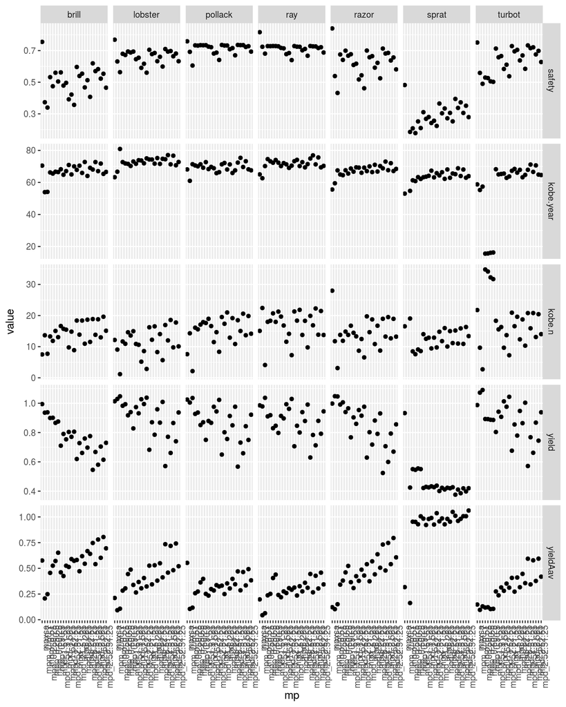

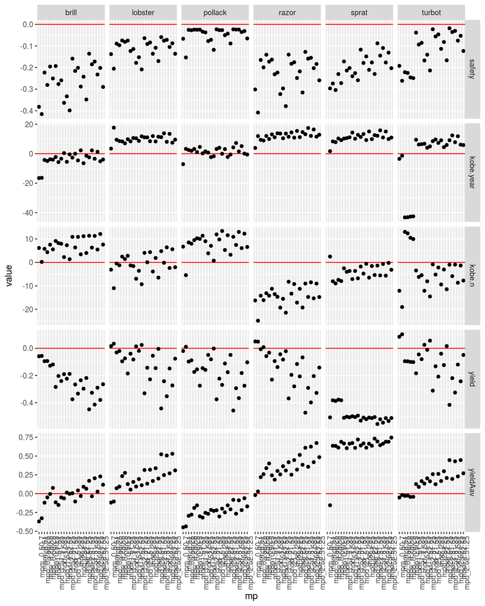

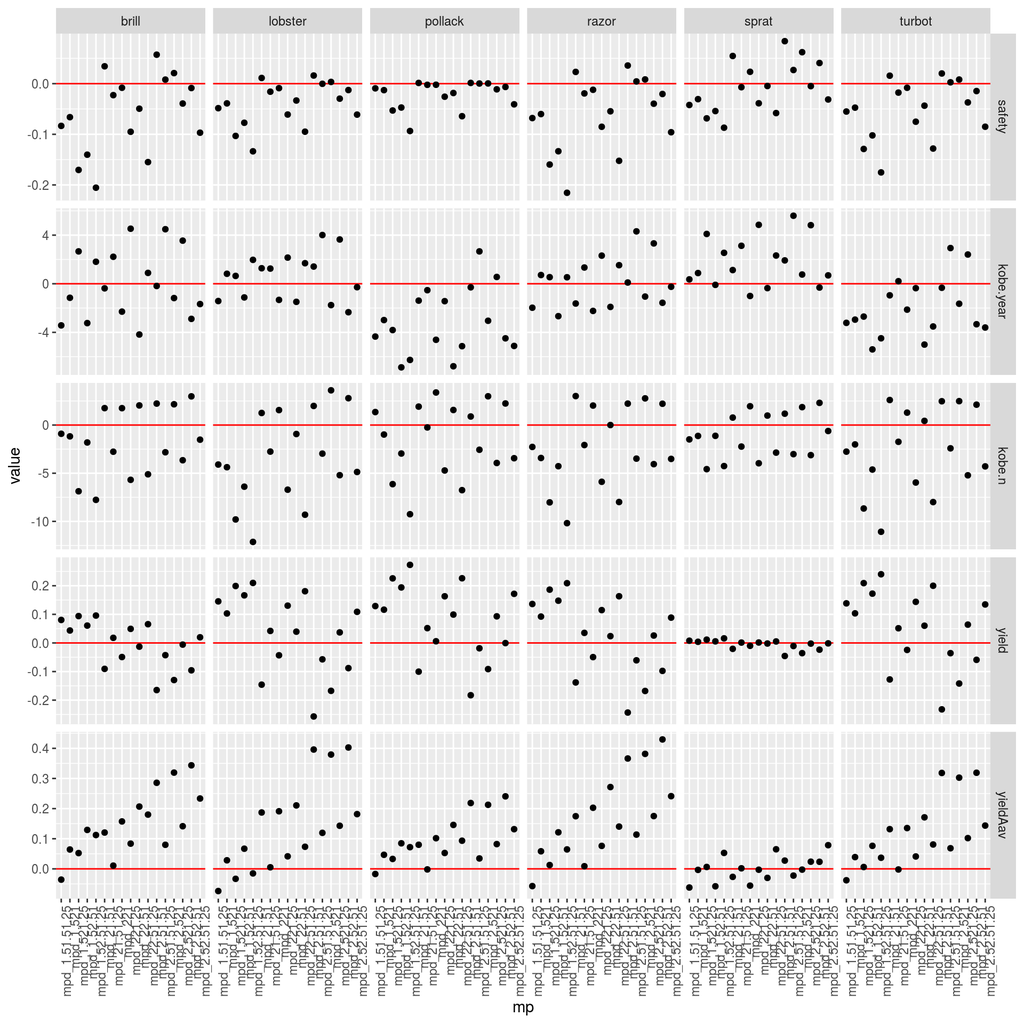

What is the most important variable

- iter
- spp
- mp
- k
- linf
- t0
- l50

## Software Versions

- R version 3.4.1 (2017-06-30)
- FLCore: 2.6.9.9009
- FLife: 3.2.1.9001
- FLBRP: 2.5.3.9001
- **Compiled**: Fri Oct 19 20:55:05 2018

## Author information

**Laurence Kell**. laurie@seaplusplus.es

## Acknowledgements

This vignette and many of the methods documented in it were developed under the MyDas project funded by the Irish exchequer and EMFF 2014-2020. The overall aim of MyDas is to develop and test a range of assessment models and methods to establish Maximum Sustainable Yield (MSY) reference points (or proxy MSY reference points) across the spectrum of data-limited stocks.

# References

Look at this example where utility=k1*k2 and k1 decreases utility and k2 increases it

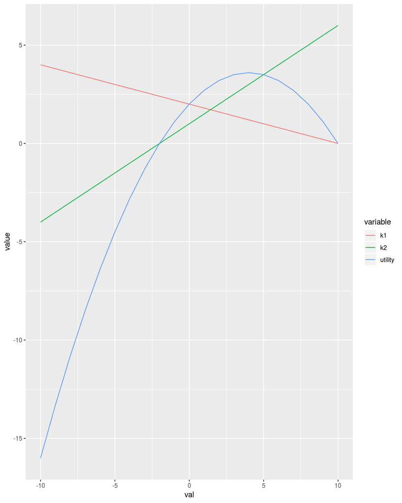

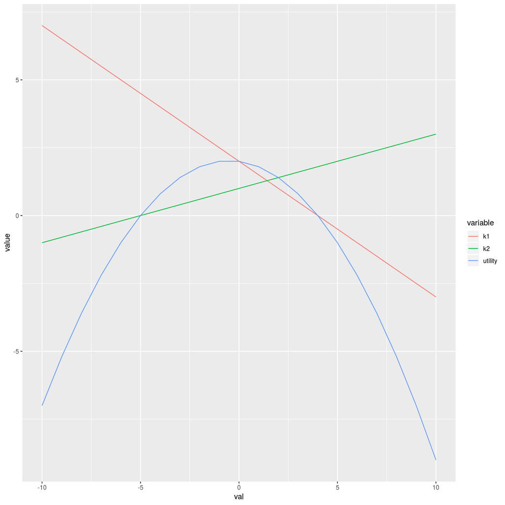

https://towardsdatascience.com/automated-machine-learning-hyperparameter-tuning-in-python-dfda59b72f8a